# REMC isoform analysis - junctions

Gloria Li  
Wed Mar 12 18:00:27 2014

## Junction coverage and RPKM distribution

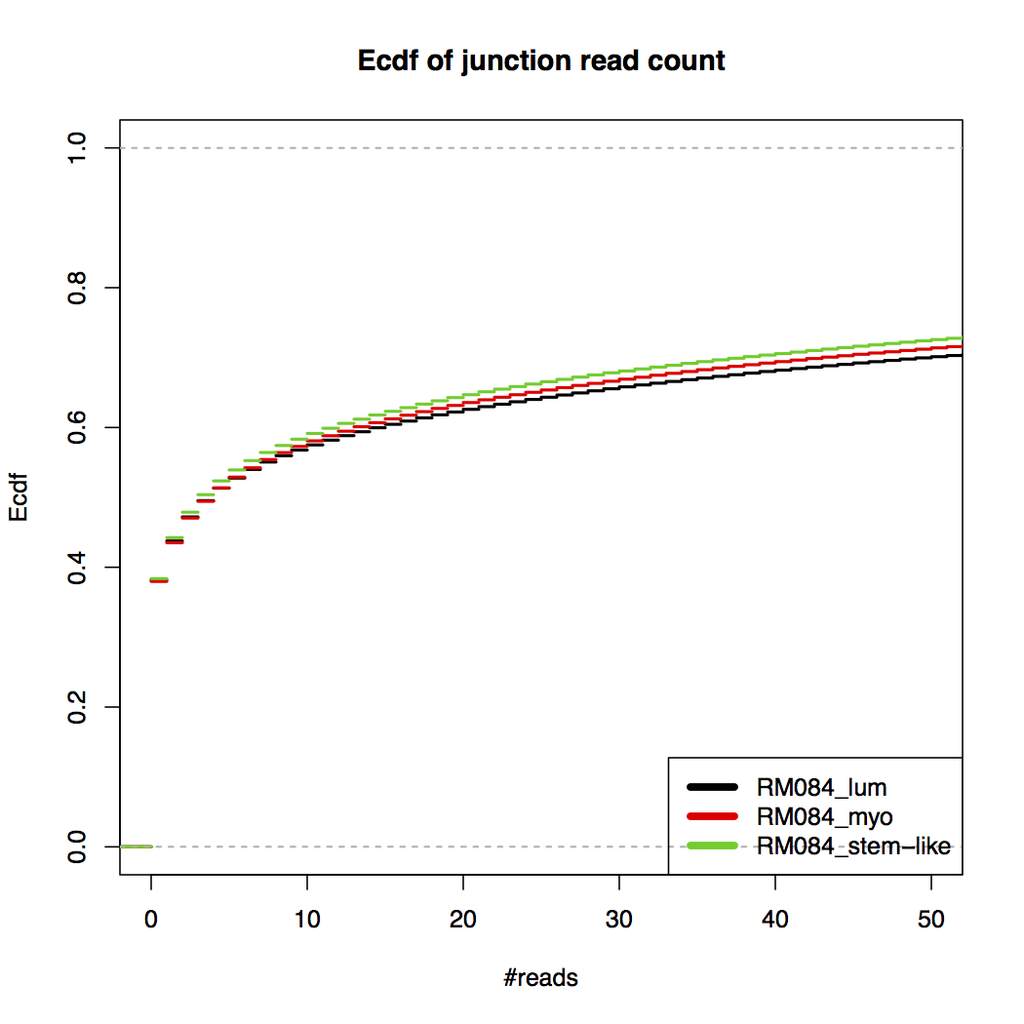

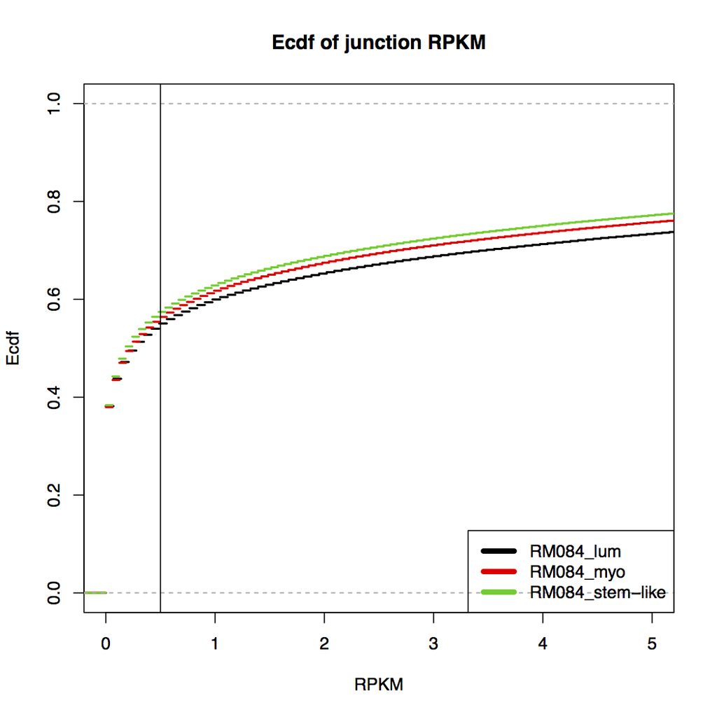

## Validate previously identified isoform genes with junctions

- Approach: For each AS gene in the previous pairwise comparison
  - Junction coverage cutoff: sum of junction coverage of two samples > 3
  - Find junctions associated with this gene with enough coverage
  - Calculate junction RPKM fold change between the 2 samples
  - The highest junction fold change > 2
- Results:
  - About **60%** persent of the genes have junctions with enough coverage for validation. Among them, **> 90%** have junctions with more than 2-fold change in RPKM.

|  | No.isoforms | with.junction.cov | with.junction.support |
| --- | --- | --- | --- |
| lum084_myo084 | 2381 | 1479 | 1365 |
| lum084_stem084 | 2429 | 1632 | 1551 |
| myo084_stem084 | 2427 | 1504 | 1422 |

- Enrichment of validated genes

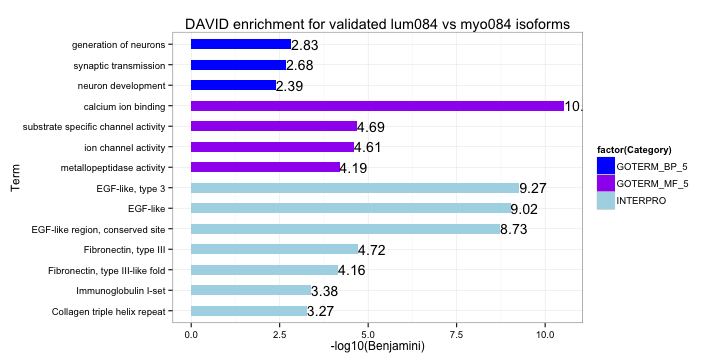

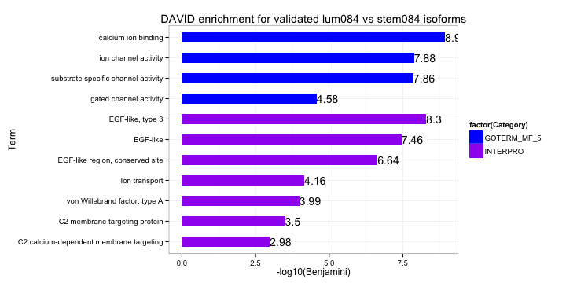

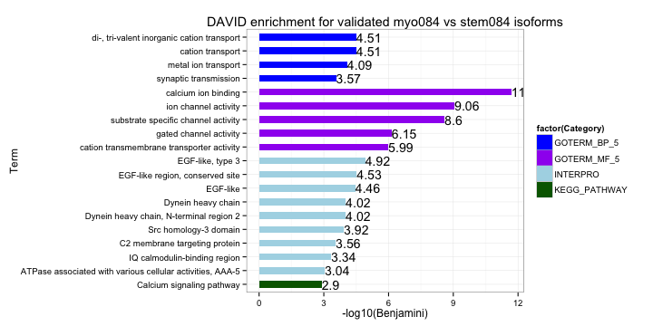

- Some screenshot examples.
  - ENSG00000170312: CDK1 (Cyclin-Dependent Kinase 1) play important regulatory roles in cell cycle control, is essential for G1/S and G2/M phase transitions of eukaryotic cell cycle.

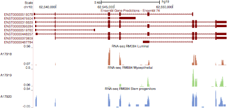

  - ENSG00000196208: GREB1 (Growth Regulation By Estrogen In Breast Cancer 1) an estrogen-responsive gene, that is an early response gene in the estrogen receptor-regulated pathway. It is thought to play an important role in hormone-responsive tissues and cancer.

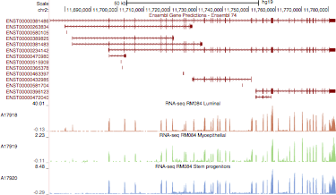

## Identify isoforms with junctions

Results from all below approaches **do not correlate well** with previously identified isoforms from exon analysis. Problem with junction alignment resulting in no coverage for many junctions?

### Fold change + junction RPKM cutoff

|  | No.junctions.2-fold | No.junctions.RPKM.5 | exclude.DE.genes | No.AS.genes | previous.genes | intersect |
| --- | --- | --- | --- | --- | --- | --- |
| lum084_myo084 | 219339 | 29392 | 22762 | 8387 | 2381 | 814 |
| lum084_stem084 | 237922 | 38434 | 28825 | 9114 | 2429 | 1023 |
| myo084_stem084 | 217178 | 28540 | 21609 | 8009 | 2427 | 790 |

### DEfine + junction RPKM cutoff

- Approach:
  - DEfine on junction RPKM (FDR = 0.015)
  - one sample junction RPKM > 0.5, the other < 0.5
  - exclude DE genes identified by DEfine (FRD = 0.015)
- Results: seems too **stringent**

|  | No.junctions.DEfine | No.junctions.RPKM.5 | exclude.DE.genes | No.AS.genes | previous.genes | intersect |
| --- | --- | --- | --- | --- | --- | --- |
| lum084_myo084 | 10919 | 4903 | 1172 | 570 | 2381 | 81 |
| lum084_stem084 | 14627 | 6984 | 1248 | 514 | 2429 | 105 |
| myo084_stem084 | 12546 | 5099 | 933 | 486 | 2427 | 103 |

### Relative junction expression

- Approach:
  - calculate relative junction expression levels: junction RPKM / gene RPKM
  - fold change in relative junction expression > 4
  - relative junction expression > 0.5 in at least one sample
  - gene RPKM > 0.1 in both samples
  - exclude DE genes identified by DEfine (FRD = 0.015)

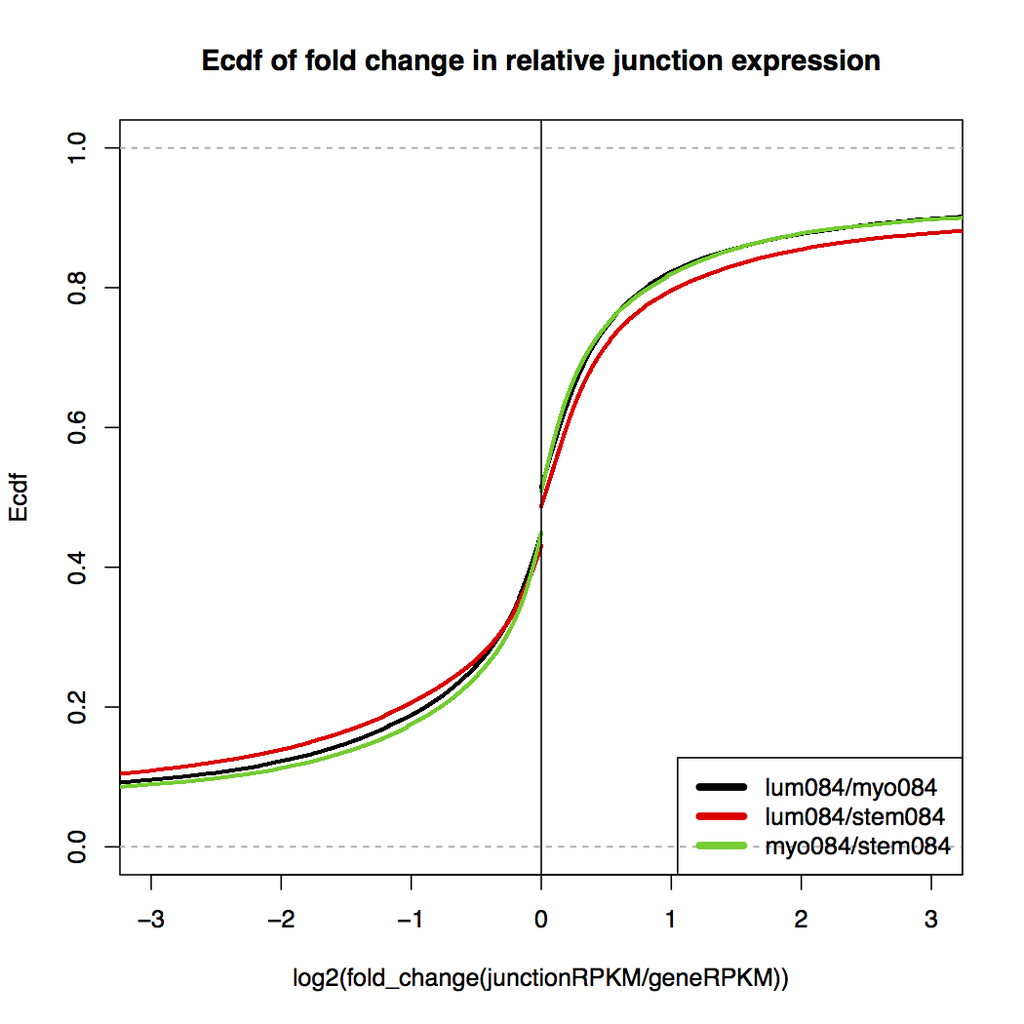

- Results: in general **better** than other approaches, but very sensitive to **genes with small RPKM**.

|  | relative.4-fold | junctions.relative.5 | geneRPKM.1 | exclude.DE.genes | No.AS.genes | previous.genes | intersect |
| --- | --- | --- | --- | --- | --- | --- | --- |
| lum084_myo084 | 82346 | 33171 | 6516 | 6034 | 1835 | 2381 | 417 |
| lum084_stem084 | 94920 | 37375 | 6678 | 6075 | 1886 | 2429 | 402 |
| myo084_stem084 | 78794 | 32372 | 5968 | 5570 | 1645 | 2427 | 426 |

### Combine exons and juntions

- Approach:
  - exon DE identified by DEfine (FDR = 0.015)
  - exon with at least one junction identified by DEfine (FDR = 0.03)
  - the exon and the junction change in the same direction
  - exclude DE genes identified by DEfine (FRD = 0.015)
- Results: still too **stringent** even with a more relaxed FDR cutoff

|  | DEfine.exons | exclude.DE.genes | with.annotated.junction | with.junction.support |
| --- | --- | --- | --- | --- |
| lum084_myo084 | 43427 | 29561 | 27987 | 622 |
| lum084_stem084 | 51457 | 34521 | 32660 | 1131 |
| myo084_stem084 | 45615 | 30066 | 28248 | 537 |